# Data, Code & RStudio

Lab 1A

Directions: Follow along with the slides, completing the questions in **blue** on your computer, and answering the questions in **red** in your journal.  
Space, Click, Right Arrow or swipe left to move to the next slide.

# Welcome to the labs!

- Throughout the year, you’ll be putting your data science skills to work by completing the labs.
- You’ll learn how to program in the `R` programming language.
  - The programming language used by actual data scientists.
- Your code will be written in RStudio which is an easy to use interface for coding using `R`.

# So let’s get started!

- The data for our first few labs comes from the Centers for Disease Control (CDC)
  - The CDC is a federal institution that studies public health.
- Type these two commands into your console:

```r
data(cdc)
```

```r
View(cdc)
```

- Describe the data that appeared after running `View(cdc)`:
  - **(1) *Who* is the information about?**
  - **(2) What sorts of information about them was collected?**
- To find out more information about the `cdc` data, type the command below into your console.
  - To get back to the slides find and click on the *Viewer* tab.

```r
?cdc
```

# Data: Variables & Observations

- Data can be broken up into two parts.
  1. *Observations*
  2. *Variables*
  - *Observations* are the *who* or *what* we are collecting data from/about.
  - *Variables* are the measurements or characteristics about our *observations*.
- If need be, re-type the command you used to `View` your data. Then answer the following:
  - **(3) Based on the data, describe a few characteristics about the first observation.**
  - **(4) What does the first column tell us about our observations?**
- In order to describe the first observation, notice that you had to look at the first row of the spreadsheet. Each row, in this case, describes a person.
- The columns of the spreadsheet represent variables.

# Uncovering our Data’s Structure

- Now that we’ve looked at our data, let’s look at how RStudio is organized.
- RStudio’s main window is composed of four *panes*.
- Find the pane that has a *tab* titled *Environment* and click on the *tab*.
  - This pane contains a list of everything that’s currently available for `R` to use.
  - Notice that `R` knows we have our `cdc` data loaded.
- **(5) How many students are in our `cdc` dataset?**
- **(6) How many variables were measured for each student?**

# Some new functions

- Type the following commands into the console:

```r
dim(cdc)
```

```r
nrow(cdc)
```

```r
ncol(cdc)
```

```r
names(cdc)
```

- **(7) Which of these functions tell us the number of observations in our data?**
- **(8) Which of these functions tell us the number of variables?**

# First Steps

- Typing commands into the console is your first step into the larger world of *programming* or *coding* (terms which are often used interchangeably).
- Coding is all about learning how to send instructions to your computer.
  - The way we *speak* to the computer, using a coding language, is *syntax*.
- `R` is one of many coding languages. Each coding language is slightly different, and these differences are reflected in the syntax.
- *Capitalization*, *spelling* and *punctuation* are REALLY important.

# Syntax matters

- Run the following commands.

```r
Names(cdc)
```

```r
NAMES(cdc)
```

```r
names(cdc)
```

```r
names(CDC)
```

- **(9) What happens after each command?**
- **(10) Which does `R` understand?**

# R’s most important syntax

- Most of the commands you will be using follow the syntax below:

```r
function(y ~ x, data = ___)
```

- To create graphs or plots you need to provide `R` with the following:
  - The name of the `R` function, often the plot’s name, that tells the computer how to create your graph.
  - The variable(s) containing the information we want the function to use.
  - The dataset containing the variables.
- Notice that when we analyze a single variable the value for *y* is left blank.

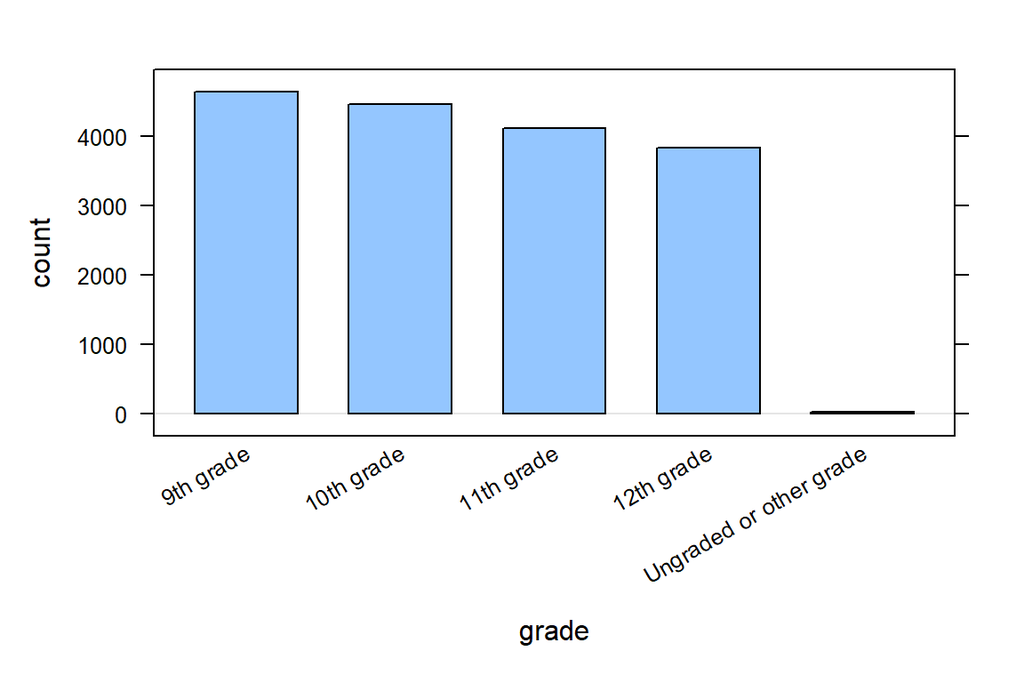

```r
bargraph(~grade, data = cdc)
```

- Later on, we’ll see we can use this syntax to do more than create graphs.

# Syntax in action

- Search through the different panes. Find and then click on the *Plots* tab.
  - To get back to the slides, find and then click on the *Viewer* tab.
- **(11) Which one of these plots would be useful for answering the question: *Is it unusual for students in the CDC dataset to be taller than 1.8 meters?***
- Run the three commands below then answer the question that follows.

```r
histogram(~height, data = cdc)
```

```r
bargraph(~drive_text, data = cdc)
```

```r
xyplot(weight~height, data = cdc)
```

- **(12) Do you think it’s unusual for students in the data to be taller than 1.8 meters? Why or why not?**
- Hint: Use the arrow keys on the *Plots* tab to toggle between the plots.

# On your own

- After completing the lab, answer the following questions:
  - **(13) What is *public health* and do we collect data about it?**
  - **(14) How do you think our data was collected? Does it include every high school aged student in the US?**
  - **(15) How might the CDC use this data? Who else could benefit from using this data?**
  - **(16) Write the code to visualize the distribution of weights of the students in the CDC data with a `histogram`.** **What is the *typical* weight?**
  - **(17) Write the code to create a `bargraph` to visualize the distribution of how often students ate fruit.** **About how many students did not eat fruit over the previous 7 days?**